# Testing affect regulation via computational modeling of real-time alcohol choices in daily life: Drift Rate

### 4.3.4 Predicted vs. Observed

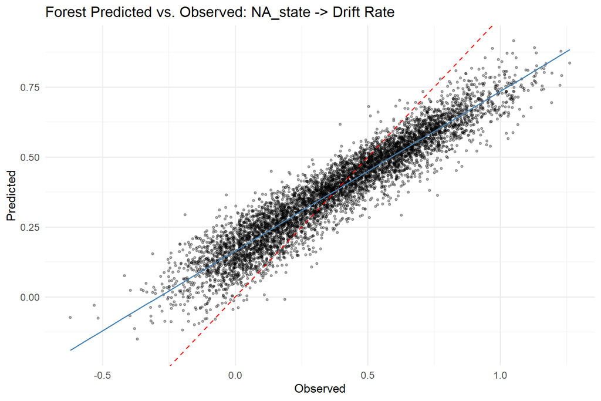

## 4.4 Model Comparison

### 4.4.1 RMSE Comparison (all methods and feature sets)

| Method | Raw | PCA | UMAP |
| --- | --- | --- | --- |
| glmm | 0.3076 | 0.3063 | 0.3047 |
| forest | 0.2555 | 0.2848 | 0.2703 |
| tree | 0.3011 | 0.3020 | 0.3039 |

# 5 Positive Affect State (PA_state)

## 5.1 Dimensionality Reduction

- **PCA components (80% variance, max 5):** 5
- **UMAP components (matching PCA):** 5

### 5.1.1 PCA Component Composition (top 5 correlated variables)

**PC_1**

| Variable | Correlation |
| --- | --- |
| alc_exp_energeticYes | -0.576 |
| alc_exp_better_moodYes | -0.557 |
| alc_exp_sociableYes | -0.547 |
| alc_exp_buzzYes | -0.502 |
| alc_craving | -0.487 |

**PC_2**

| Variable | Correlation |
| --- | --- |
| alc_exp_injuryYes | -0.595 |
| alc_exp_be_rudeYes | -0.593 |
| alc_exp_embarrassedYes | -0.578 |
| alc_exp_nauseous_vomitYes | -0.491 |
| alc_exp_hangoverYes | -0.467 |

**PC_3**

| Variable | Correlation |
| --- | --- |
| locationschool_work | 0.590 |
| alc_today | -0.578 |
| alc_cuenone | 0.569 |
| time_of_dayevening | -0.476 |
| locationhome | -0.456 |

**PC_4**

| Variable | Correlation |
| --- | --- |
| soft_yday | 0.698 |
| soft_today | 0.649 |
| soft_intend | 0.633 |
| soft_craving | 0.489 |
| alc_exp_embarrassedYes | -0.389 |

**PC_5**

| Variable | Correlation |
| --- | --- |
| locationhome | -0.634 |
| social_context_aloneYes | -0.558 |
| social_context_friend_roommateYes | 0.500 |
| social_context_strangerYes | 0.417 |
| locationsomeone_elses_home | 0.371 |

### 5.1.2 UMAP Component Composition (top 5 correlated variables)

**UMAP_1**

| Variable | Correlation |
| --- | --- |
| alc_exp_embarrassedYes | 0.297 |
| alc_exp_be_rudeYes | 0.294 |
| alc_craving | 0.289 |
| alc_intend | 0.251 |
| alc_yday | 0.192 |

**UMAP_2**

| Variable | Correlation |
| --- | --- |
| alc_yday | -0.251 |
| alc_exp_embarrassedYes | 0.128 |
| alc_exp_be_rudeYes | 0.125 |
| alc_mot_enhanceYes | -0.112 |
| alc_intend | -0.098 |

**UMAP_3**

| Variable | Correlation |
| --- | --- |
| alc_yday | -0.439 |
| alc_today | -0.370 |
| soft_craving | 0.177 |
| alc_exp_be_rudeYes | 0.166 |
| alc_exp_embarrassedYes | 0.161 |

**UMAP_4**

| Variable | Correlation |
| --- | --- |
| soft_yday | 0.802 |
| soft_today | 0.687 |
| soft_intend | 0.574 |
| soft_craving | 0.303 |
| alc_exp_be_rudeYes | 0.174 |

**UMAP_5**

| Variable | Correlation |
| --- | --- |
| alc_exp_injuryYes | 0.507 |
| alc_exp_nauseous_vomitYes | 0.366 |
| alc_exp_embarrassedYes | 0.351 |
| alc_exp_be_rudeYes | 0.350 |
| alc_exp_hangoverYes | 0.196 |

## 5.2 GLMM Results

### 5.2.1 Raw Features

- **Optimal lambda:** 60 (index 9 of 21)
- **CV RMSE:** 0.3097

**Non-zero coefficients** (focal predictor terms highlighted):

| Term | Estimate | Category |
| --- | --- | --- |
| (Intercept) | 0.4137 | Intercept |
| PA_state | -0.0039 | Focal predictor |
| alc_exp_embarrassedYes | -0.0394 | Covariate main effect |
| alc_exp_injuryYes | -0.0380 | Covariate main effect |
| alc_exp_be_rudeYes | -0.0325 | Covariate main effect |
| alc_exp_hangoverYes | -0.0237 | Covariate main effect |
| alc_exp_nauseous_vomitYes | -0.0223 | Covariate main effect |
| alc_exp_relaxedYes | 0.0204 | Covariate main effect |
| alc_exp_better_moodYes | 0.0118 | Covariate main effect |
| alc_cuenone | -0.0101 | Covariate main effect |
| alc_mot_enhanceYes | 0.0066 | Covariate main effect |
| alc_mot_copingYes | 0.0052 | Covariate main effect |
| soft_today | -0.0045 | Covariate main effect |
| alc_intend | 0.0045 | Covariate main effect |
| soft_intend | -0.0045 | Covariate main effect |
| alc_craving | 0.0043 | Covariate main effect |
| alc_exp_buzzYes | 0.0035 | Covariate main effect |
| soft_yday | -0.0029 | Covariate main effect |
| locationother | 0.0022 | Covariate main effect |
| bored_state | 0.0012 | Covariate main effect |
| alc_yday | 0.0007 | Covariate main effect |
| alc_exp_sociableYes | -0.0007 | Covariate main effect |
| time_of_dayevening | -0.0007 | Covariate main effect |
| social_context_familyYes | -0.0006 | Covariate main effect |
| thirst_state | 0.0004 | Covariate main effect |
| responsibilityYes | -0.0004 | Covariate main effect |
| alc_exp_injuryYes:PA_state | -0.0208 | Interaction with focal predictor |
| alc_exp_embarrassedYes:PA_state | -0.0199 | Interaction with focal predictor |
| alc_exp_be_rudeYes:PA_state | -0.0178 | Interaction with focal predictor |
| alc_exp_hangoverYes:PA_state | -0.0104 | Interaction with focal predictor |
| alc_exp_nauseous_vomitYes:PA_state | -0.0104 | Interaction with focal predictor |
| alc_cuenone:PA_state | -0.0050 | Interaction with focal predictor |
| time_of_dayevening:PA_state | -0.0045 | Interaction with focal predictor |
| alc_exp_relaxedYes:PA_state | 0.0036 | Interaction with focal predictor |
| responsibilityYes:PA_state | -0.0024 | Interaction with focal predictor |
| soft_intend:PA_state | -0.0021 | Interaction with focal predictor |
| soft_today:PA_state | -0.0019 | Interaction with focal predictor |
| locationhome:PA_state | -0.0015 | Interaction with focal predictor |
| alc_exp_sociableYes:PA_state | -0.0014 | Interaction with focal predictor |
| soft_yday:PA_state | -0.0013 | Interaction with focal predictor |
| social_context_familyYes:PA_state | -0.0013 | Interaction with focal predictor |
| alc_intend:PA_state | 0.0011 | Interaction with focal predictor |
| alc_exp_better_moodYes:PA_state | 0.0011 | Interaction with focal predictor |
| alc_craving:PA_state | 0.0008 | Interaction with focal predictor |
| soft_craving:PA_state | -0.0008 | Interaction with focal predictor |
| social_context_aloneYes:PA_state | -0.0007 | Interaction with focal predictor |
| day_of_weekSun:PA_state | -0.0001 | Interaction with focal predictor |

- 51 coefficients penalized to zero.*

#### 5.2.1.1 Predicted vs. Observed

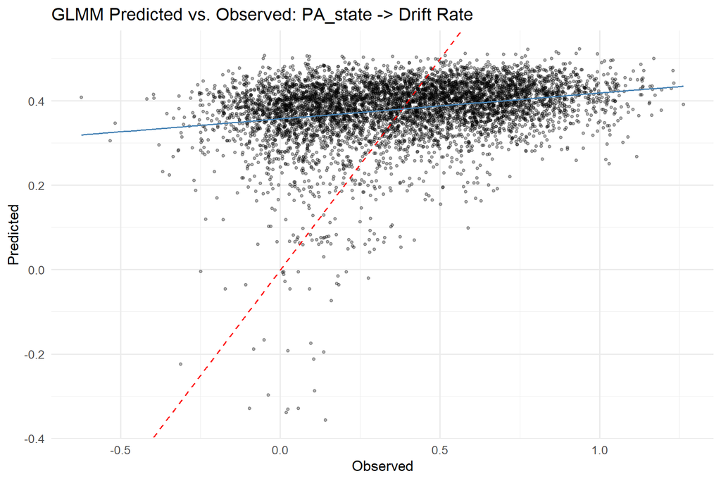

#### 5.2.1.2 Residual Diagnostics

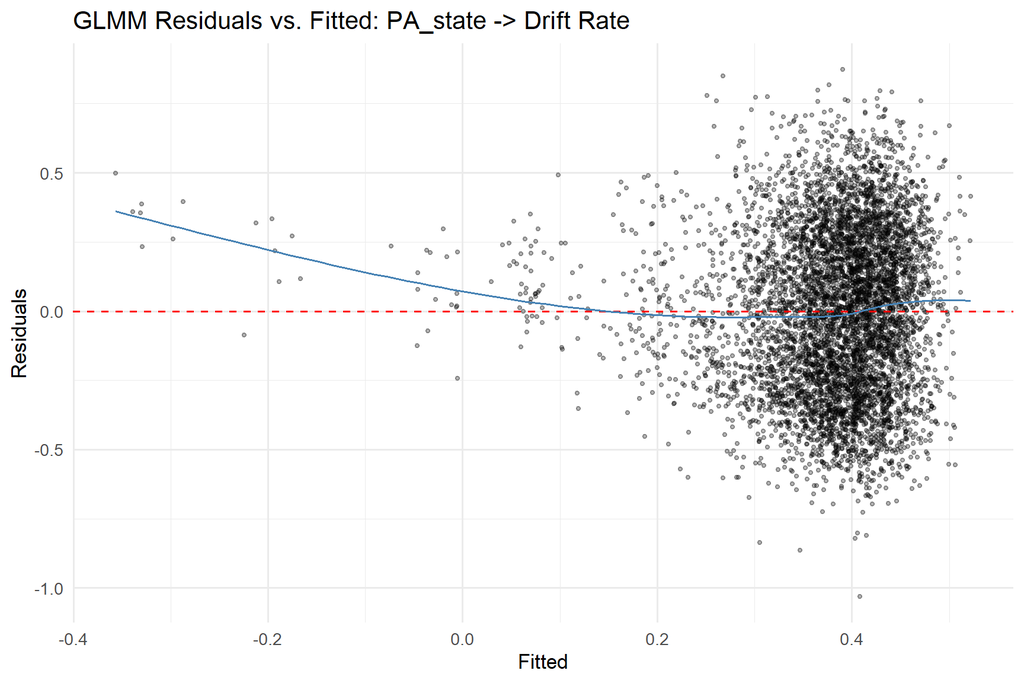

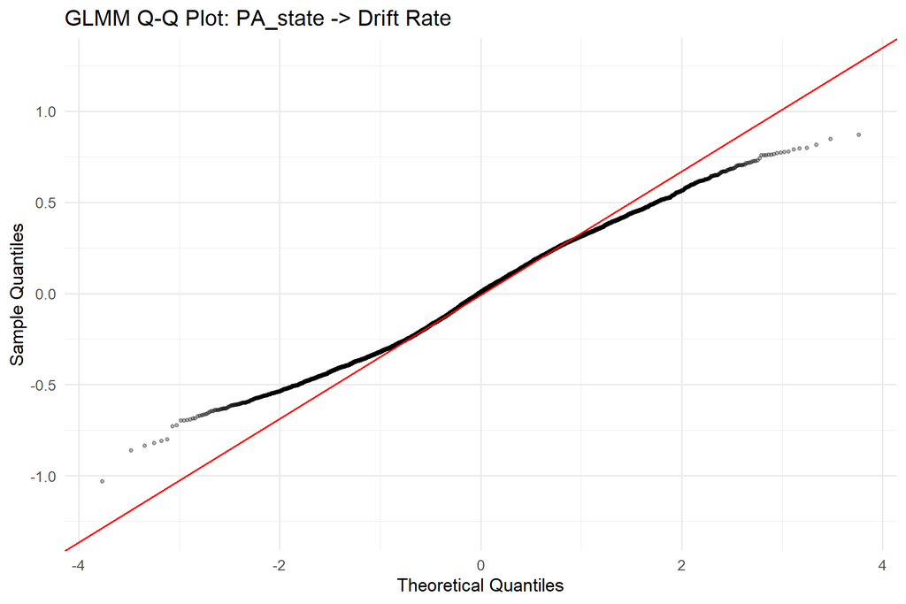

### 5.2.2 PCA Features

- **Optimal lambda:** 95 (index 2 of 21)
- **CV RMSE:** 0.3067

**Non-zero coefficients:**

| Term | Estimate |
| --- | --- |
| (Intercept) | 0.3944 |
| PC_2 | 0.0305 |
| PA_state | -0.0061 |
| PC_2:PA_state | 0.0053 |
| PC_5:PA_state | -0.0083 |

- 7 coefficients penalized to zero.*

### 5.2.3 UMAP Features

- **Optimal lambda:** 65 (index 8 of 21)
- **CV RMSE:** 0.3057

**Non-zero coefficients:**

| Term | Estimate |
| --- | --- |
| (Intercept) | 0.4045 |
| UMAP_3 | -0.0072 |
| UMAP_4 | -0.0197 |
| PA_state | -0.0115 |
| UMAP_4:PA_state | 0.0003 |
| UMAP_5:PA_state | -0.0077 |

- 6 coefficients penalized to zero.*

## 5.3 Random Forest Results (Raw)

### 5.3.1 Tuning Summary

- **mtry:** 25
- **min.node.size:** 4
- **sample.fraction:** 0.764
- **CV RMSE:** 0.2541

### 5.3.2 Variable Importance (Permutation)

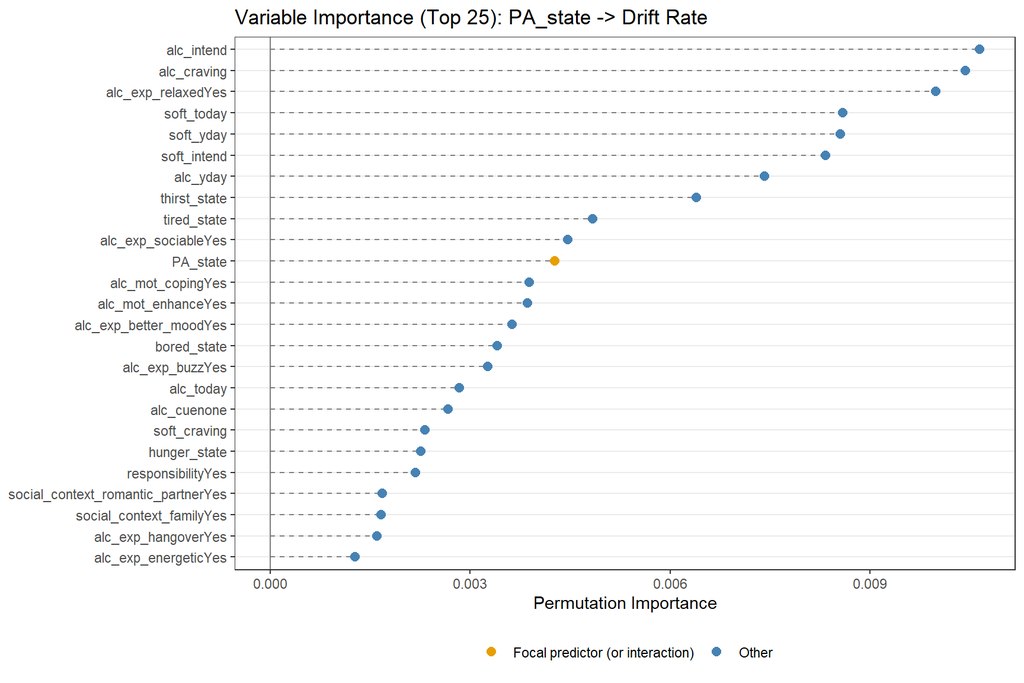

**Full importance ranking:**

| Variable | Importance |
| --- | --- |
| alc_intend | 0.010649 |
| alc_craving | 0.010435 |
| alc_exp_relaxedYes | 0.009989 |
| soft_today | 0.008590 |
| soft_yday | 0.008557 |
| soft_intend | 0.008332 |
| alc_yday | 0.007416 |
| thirst_state | 0.006399 |
| tired_state | 0.004838 |
| alc_exp_sociableYes | 0.004462 |
| PA_state | 0.004266 |
| alc_mot_copingYes | 0.003887 |
| alc_mot_enhanceYes | 0.003864 |
| alc_exp_better_moodYes | 0.003633 |
| bored_state | 0.003403 |
| alc_exp_buzzYes | 0.003265 |
| alc_today | 0.002833 |
| alc_cuenone | 0.002668 |
| soft_craving | 0.002325 |
| hunger_state | 0.002261 |
| responsibilityYes | 0.002176 |
| social_context_romantic_partnerYes | 0.001676 |
| social_context_familyYes | 0.001659 |
| alc_exp_hangoverYes | 0.001603 |
| alc_exp_energeticYes | 0.001271 |
| alc_exp_embarrassedYes | 0.001178 |
| social_context_aloneYes | 0.000990 |
| time_of_dayevening | 0.000958 |
| locationhome | 0.000781 |
| alc_exp_be_rudeYes | 0.000639 |
| alc_mot_socialYes | 0.000616 |
| locationschool_work | 0.000566 |
| locationother | 0.000376 |
| alc_exp_nauseous_vomitYes | 0.000263 |
| alc_cueindirectly_visible | 0.000223 |
| social_context_coworker_classmateYes | 0.000216 |
| social_context_strangerYes | 0.000214 |
| social_context_friend_roommateYes | 0.000213 |
| alc_exp_injuryYes | 0.000179 |
| locationoutdoors | 0.000054 |
| locationsomeone_elses_home | 0.000044 |
| day_of_weekSun | 0.000042 |
| locationrestaurant_cafe | 0.000013 |
| social_context_otherYes | 0.000012 |
| day_of_weekSat | -0.000083 |
| day_of_weekMon | -0.000090 |
| day_of_weekWed | -0.000133 |
| day_of_weekThu | -0.000216 |
| day_of_weekTue | -0.000246 |

### 5.3.3 Partial Dependence Plots

PDP for the focal predictor and the top 5 most important non-interaction covariates.

#### 5.3.3.1 Focal Predictor: PA_state

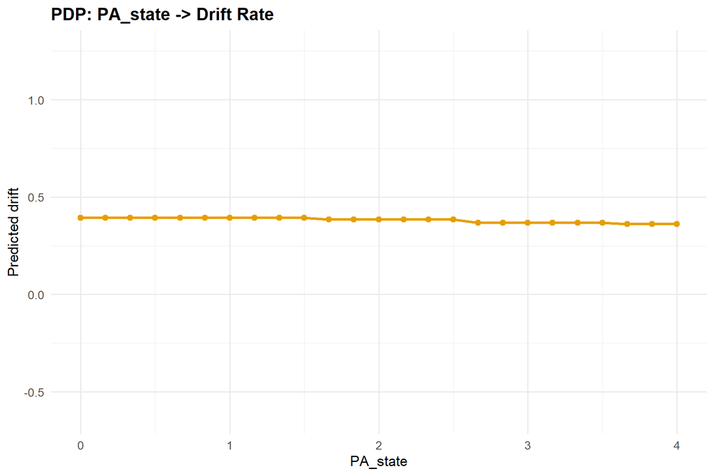

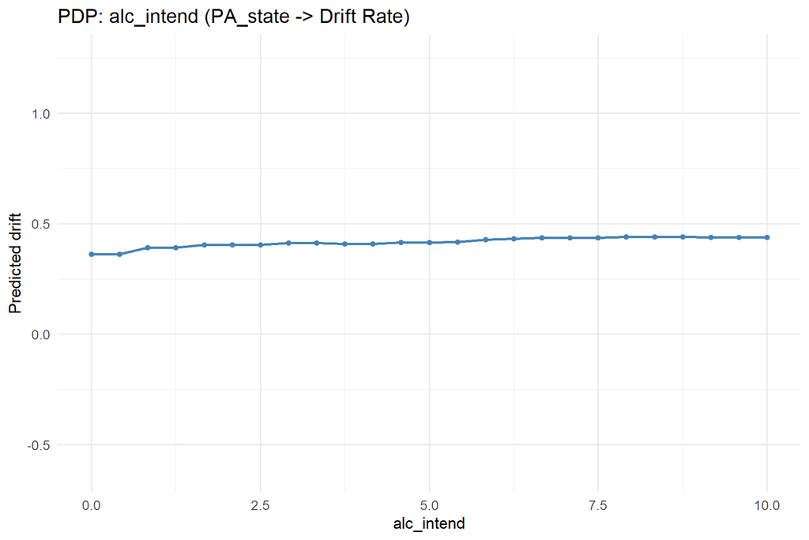

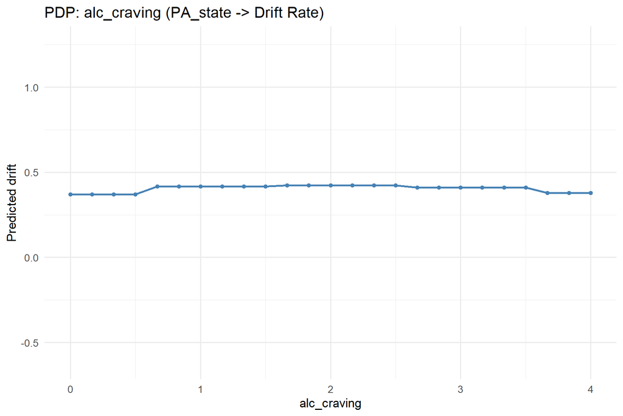

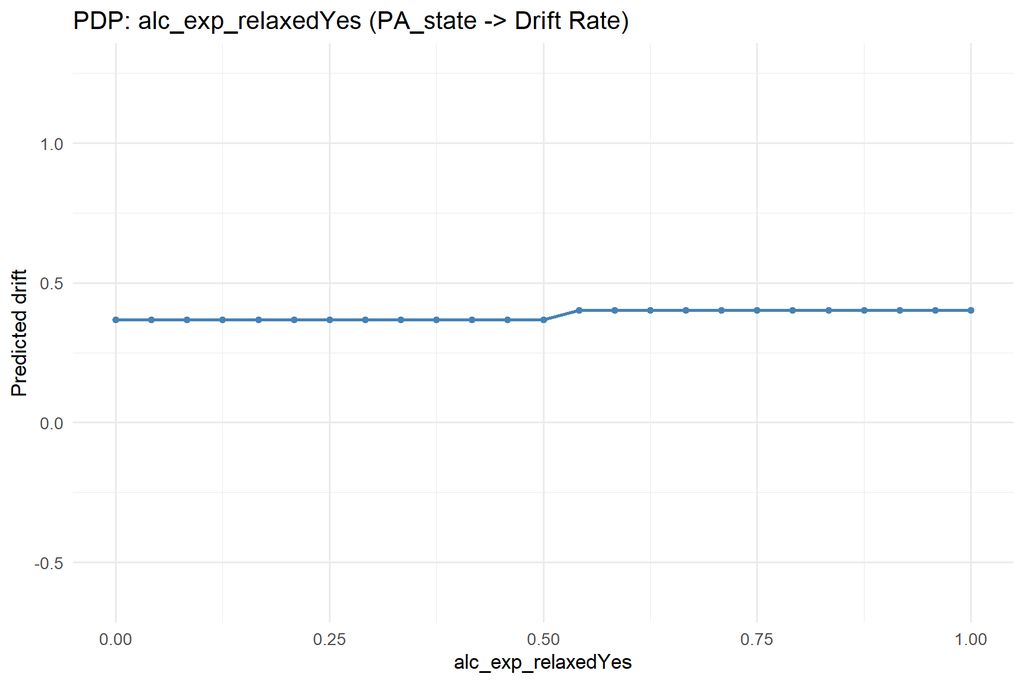

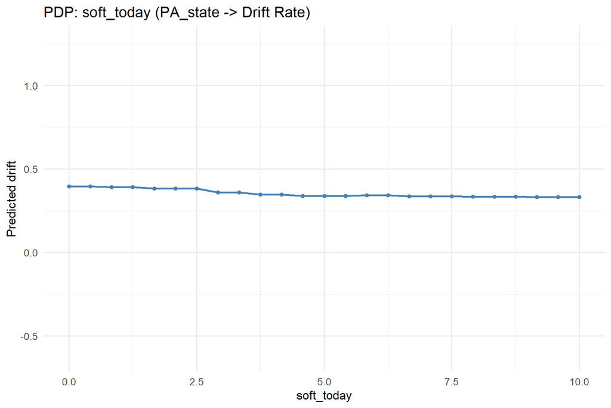

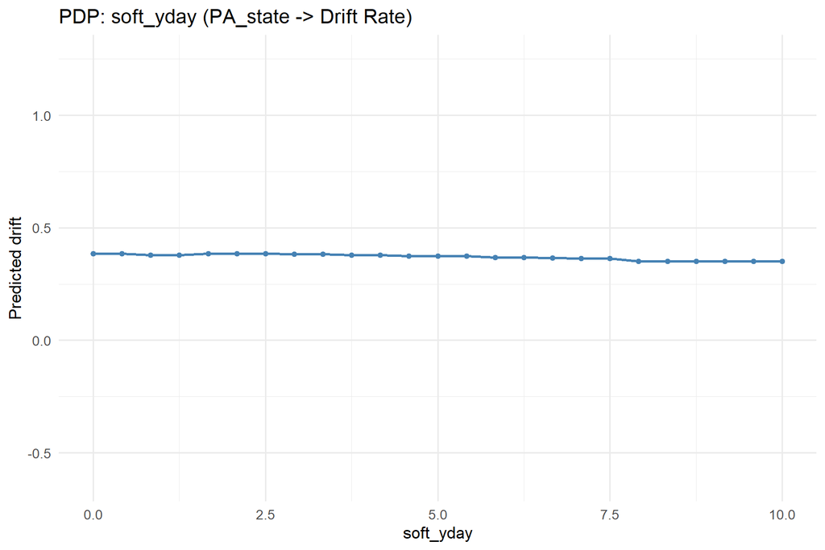

### 5.3.4 Predicted vs. Observed

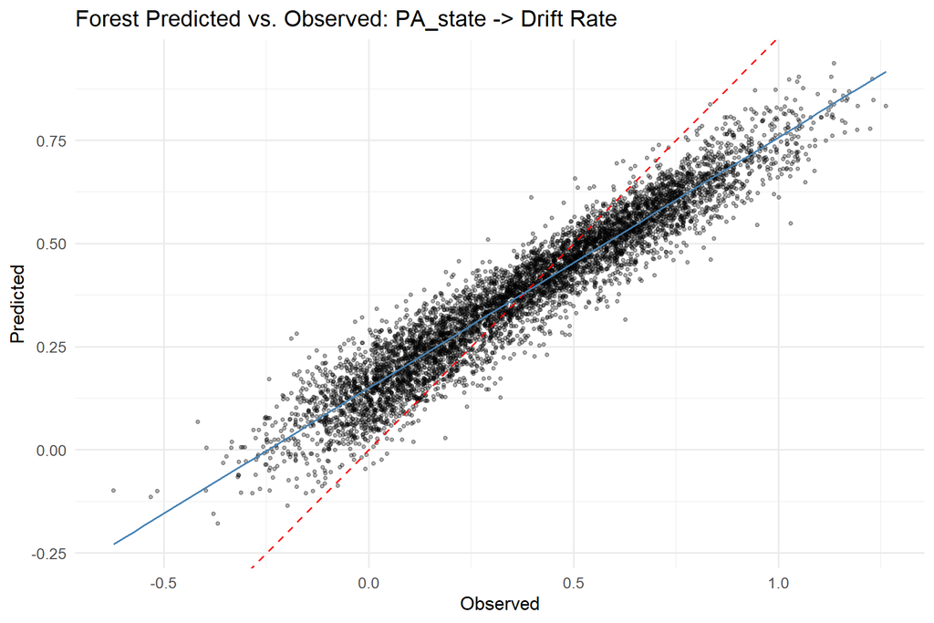

## 5.4 Model Comparison

### 5.4.1 RMSE Comparison (all methods and feature sets)

| Method | Raw | PCA | UMAP |
| --- | --- | --- | --- |
| glmm | 0.3097 | 0.3067 | 0.3057 |
| forest | 0.2541 | 0.2827 | 0.2702 |
| tree | 0.3035 | 0.3026 | 0.3046 |

*Note: The MetaForest package (`metaforest`) uses random forests designed for meta-analytic data, where observations have known sampling variances and are nested within studies. While the clustering structure (observations within participants) is conceptually similar to EMA data, MetaForest specifically requires sampling variance estimates (`vi`) that are not available in this context. The analytical patterns from that framework (variable importance, partial dependence) have been adopted above without the MetaForest package itself.*